# 5 Vectors

There are examples where numbers are naturally paired off, for example a point in the $x$-$y$ plane is naturally represented by a pair of numbers. A bit more generally, we have an example from physics of describing the laws of motion of a projectile, such as an arrow flying when wind effects are not known. A two-dimensional picture represents the trajectory with $y$ as the height and $x$ the distance from the shooter. The projectile itself has three main quantities of interest: its position, its velocity and its acceleration. Each in turn has two components – one in the $x$ direction and one in the $y$.

The basic equations of motion are derived from Newton’s laws and govern the position, velocity, and acceleration of the projectile. The formulas depend on an initial position, which we take to be $\langle x_0,~ y_0 \rangle$, an initial velocity $\langle v_{0x},~ v_{0y} \rangle$, and time $t > 0$. The three values for a given time $t$ are then:
$$~
\begin{align}
\vec{x} &= \langle x_0 + v_{0x}t,~ -(1/2) g t^2 + v_{0y}t + y_0 \rangle,\\
\vec{v} &= \langle v_{0x},~ -gt + v_{0y}t \rangle, \text{ and }\\
\vec{a} &= \langle 0,~ -g \rangle.
\end{align}
~$$

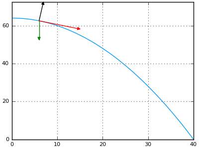

Position, velocity, and acceleration vectors (scaled) for projectile motion. Vectors are drawn with tail on the projectile. The position vector (black) points from the origin to the projectile, the velocity vector (red) is in the direction of the trajectory, and the acceleration vector (green) is a constant pointing downward.

We have used the notation $\langle x,~ y \rangle$ to collect the two values into a single object, which we indicate through a label on the variable name. These are vectors, and we shall see they find use far beyond this application.

A line segment in the plane connects two points $(x_0, y_0)$ and $(x_1, y_1)$. The length of a line segment (its magnitude) is given by the distance formula $\sqrt{(x_1 - x_0)^2 + (y_1 - y_0)^2}$. A line segment can be given a direction by assigning an initial point and a terminal point. A directed line segment has both a direction and a magnitude. A vector is an abstraction where just these two properties – a direction and a magnitude – are intrinsic. While a directed line segment can be represented by a vector, a single vector describes all such line segments found by translation. That is, how the the vector is located when visualized is for convenience, it is not a characteristic of the vector. In the figure above, all vectors are drawn with their tails at the position of the projectile over time.

We can visualize a vector as an arrow in two-dimensional space. This arrow has two components. We represent a vector than mathematically as $\langle x,~ y \rangle$. For example, the vector connecting the point $(x_0, y_0)$ to $(x_1, y_1)$ is $\langle x_1 - x_0,~ y_1 - y_0 \rangle$.

The magnitude of a vector comes from the distance formula, and is $\| \vec{v} \| = \sqrt{x^2 + y^2}$.

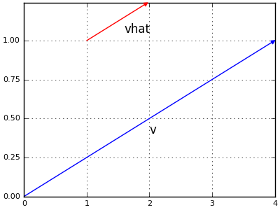

A vector and its unit vector. They share the same direction, but the unit vector has a standardized magnitude.

We call the values $x$ and $y$ of the vector $\vec{v} = \langle x,~ y \rangle$ the components of the $v$.

Two operations on vectors are fundamental.

- Vectors can be multiplied by a scalar (a real number): $c\vec{v} = \langle cx,~ cy \rangle$. Geometrically this scales the vector by a factor of $\lvert c \rvert$ and switches the direction of the vector by 180 degree when $c < 0$. A *unit vector* is one with magnitude 1, and, except for the $\vec{0}$ vector, can be formed from $\vec{v}$ by dividing $\vec{v}$ by its magnitude. A unit vector gives the direction of a vector and its norm the magnitude.
- Vectors can be added: $\vec{v} + \vec{w} = \langle v_x + w_x,~ v_y + w_y \rangle$. That is, each corresponding component adds to form a new vector. Similarly for subtraction. The $\vec{0}$ vector then would be just $\langle 0,~ 0 \rangle$ and would satisfy $\vec{0} + \vec{v} = \vec{v}$ for any vector $\vec{v}$. The vector addition $\vec{v} + \vec{w}$ is visualized by placing the tail of $\vec{w}$ at the tip of $\vec{v}$ and then considering the new vector with tail coming from $\vec{v}$ and tip coming from the position of the tip of $\vec{w}$. Subtraction is different, place both the tails of $\vec{v}$ and $\vec{w}$ at the same place and the new vector has tail at the tip of $\vec{v}$ and tip at the tip of $\vec{w}$.

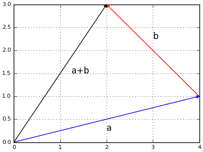

The sum of two vectors can be visualized by placing the tail of one at the tip of the other

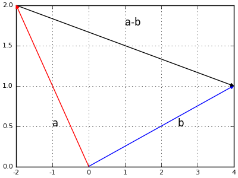

The concept of scalar multiplication and addition, allow the decomposition of vectors into standard vectors. The standard unit vectors in two dimensions are $e_x = \langle 1,~ 0 \rangle$ and $e_y = \langle 0,~ 1 \rangle$. Any two dimensional vector can be written uniquely as $a e_x + b e_y$ for some pair of scalars $a$ and $b$ (or as, $\langle a, b \rangle$). This is true more generally where the two vectors are not the standard unit vectors – they can be *any* two non-parallel vectors.

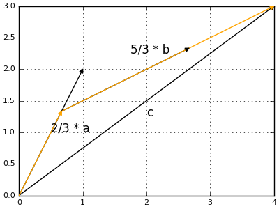

The vector $\langle 4,3 \rangle$ is written as $2$/$3$ $\cdot\langle 1,2 \rangle$ $+$ $5$/$3$ $\cdot\langle 2,1 \rangle$. Any vector $\vec{c}$ can be written uniquely as $\alpha\cdot\vec{a} + \beta \cdot \vec{b}$ provided $\vec{a}$ and $\vec{b}$ are not parallel.

When a vector is placed with its tail at the origin, it can be described in terms of the angle it makes with the $x$ axis, $\theta$, and its length, $r$. The following formulas apply:
$$~
r = \sqrt{x^2 + y^2}, \quad \tan(\theta) = y/x.
~$$

If we are given $r$ and $\theta$, then the vector is $v = \langle r \cdot \cos(\theta),~ r \cdot \sin(\theta) \rangle$.

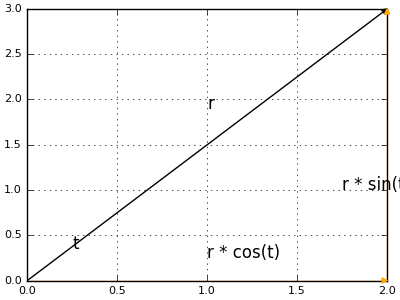

A vector $\langle x, y \rangle$ can be written as $\langle r\cdot \cos(\theta), r\cdot\sin(\theta) \rangle$ for values $r$ and $\theta$. The value $r$ is a magnitude, the direction parameterized by $\theta$.